# Property Damage and Casualties of Various Weather Events in the U.S. (2000-2011)

Cha Li

04/25/2015

### Synopsis

This analysis looks at which weather events have caused the most property damage and the most human casualties in recent time. The dataset used for this analysis is provided by the U.S. National Weather Service and contains the characteristics of various major storms and weather events between 1950 and 2011. This report focusses on recent storms, 2000 - 2011, and will show that tornadoes are the most harmful and that floods are the most damanging.

### Data Processing

#### Loading Packages and Raw Data

```r
library(reshape2)
library(lubridate)
library(dplyr)
library(ggplot2)
```

```r
raw_data <- read.csv(bzfile("raw-data/repdata-data-StormData.csv.bz2"), stringsAsFactors=F)
```

#### Data Manipulation

The storm dataset breaks damage into two categories: property and crops. Additionally, each category is given two columns to represent total damage inflicted: a base value (PROPDMG, CROPDMG) and an exponent code or value (PROPDMGEXP, CROPDMGEXP). Therefore, total damage caused by a storm is calculated with: (PROPDMG * 10 ^ PROPDMGEXP) + (CROPDMG * 10 ^ CROPDMGEXP). The problem arises in the representation of the exponent. In some instances numbers are used but others use codes such as ‘H’ for hundred, ‘K’ for thousand, ‘M’ for million, and ‘B’ for billion. As a result, most of the data cleaning is centered around converting those codes to their respective exponents. We also only focus on data from 2000 and onward as more recent data is not only more relevant but also more complete.

```r
# only use data from 2000 onward
working_data <- raw_data %>%
    mutate(BGN_DATE=mdy_hms(BGN_DATE), casualties=FATALITIES+INJURIES) %>%
    filter(BGN_DATE >= ymd("2000-01-01"))

# economic damage = property damange + crop damage
# total property and total crop damage are each divided into two columns:
#   a base value, up to 3 significant digits. PROPDMG, CROPDMG
#   a exponent value, H, K, M, B, or a numeric value. PROPDMGEXP, CROPDMGEXP
# damage = base * 10 ^ exp

# convert exponent codes (H = hundred, K = thousand, M = million, B = billion) into their proper
# exponent values. all other character codes will be converted to 0
working_data <- working_data %>%
    mutate(CROPDMGEXP=ifelse(CROPDMGEXP == 'B' | CROPDMGEXP == "b", 9, CROPDMGEXP)) %>%
    mutate(CROPDMGEXP=ifelse(CROPDMGEXP == 'M' | CROPDMGEXP == "m", 6, CROPDMGEXP)) %>%
    mutate(CROPDMGEXP=ifelse(CROPDMGEXP == 'K' | CROPDMGEXP == "k", 3, CROPDMGEXP)) %>%
    mutate(CROPDMGEXP=ifelse(CROPDMGEXP == 'H' | CROPDMGEXP == "h", 2, CROPDMGEXP)) %>%
    mutate(CROPDMGEXP=ifelse(CROPDMGEXP %in% c("", "+", "?", "-"), 0, CROPDMGEXP)) %>%
    mutate(PROPDMGEXP=ifelse(PROPDMGEXP == 'B' | PROPDMGEXP == "b", 9, PROPDMGEXP)) %>%
    mutate(PROPDMGEXP=ifelse(PROPDMGEXP == 'M' | PROPDMGEXP == "m", 6, PROPDMGEXP)) %>%
    mutate(PROPDMGEXP=ifelse(PROPDMGEXP == 'K' | PROPDMGEXP == "k", 3, PROPDMGEXP)) %>%
    mutate(PROPDMGEXP=ifelse(PROPDMGEXP == 'H' | PROPDMGEXP == "h", 2, PROPDMGEXP)) %>%
    mutate(PROPDMGEXP=ifelse(PROPDMGEXP %in% c("", "+", "?", "-"), 0, PROPDMGEXP)) %>%
    mutate(PROPDMGEXP=as.numeric(PROPDMGEXP), CROPDMGEXP=as.numeric(CROPDMGEXP))

# create some new columns for property and crop damage
working_data <- working_data %>% mutate(
    crop_damage = CROPDMG * 10 ** CROPDMGEXP,
    prop_damage = PROPDMG * 10 ** PROPDMGEXP)

# for this analysis we really only care about event type, casualties, and damage. lets cut out
# uneeded columns to save memory
working_data <- working_data %>% select(EVTYPE, FATALITIES:INJURIES, crop_damage:prop_damage)
```

### Results

#### Most Dangerous Weather Events

This section will focus on which weather events are the most dangerous to human lives as measured by casualties. Casualties include fatalities and injuries, which are seperated in the graph below.

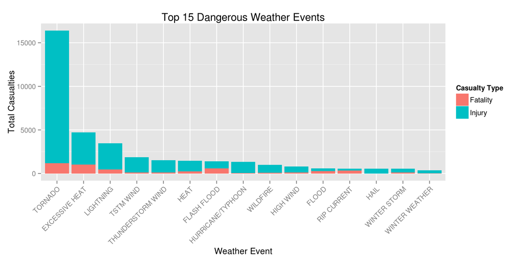

```r
# Across the United States, which types of events (as indicated in the EVTYPE variable) are most harmful with respect to population health?
event_casualties <- working_data %>%
    group_by(EVTYPE) %>%
    summarise(
        total_fatalities=sum(FATALITIES),
        total_injuries=sum(INJURIES))

# top 10 events for each casualty type
top_casualties <- event_casualties %>% arrange(desc(total_fatalities + total_injuries)) %>% head(n=15)

# these sort the data in a way so the bar plot organizes them from most to least casualties. the data
# is then melted to be in 'long format' for creating stacked bar plots
top_casualties <- transform(top_casualties, EVTYPE = reorder(EVTYPE, order(total_fatalities + total_injuries, decreasing = TRUE)))
top_casualties <- melt(top_casualties, id.var="EVTYPE")

ggplot(top_casualties, aes(x=EVTYPE, y=value, fill=variable)) +
    geom_bar(stat="identity") +
    xlab("Weather Event") +
    ylab("Total Casualties") +
    ggtitle("Top 15 Dangerous Weather Events") +
    scale_fill_discrete(name="Casualty Type", labels=c("Fatality", "Injury")) +
    theme(axis.text.x = element_text(angle = 45, hjust = 1))
```

We now look at the most damaging weather events. Damage is measued in US Dollars and is split between property damage and crop damage.

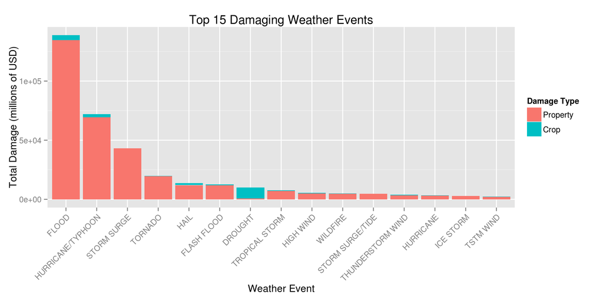

```r
# Across the United States, which types of events have the greatest economic consequences?
event_damage <- working_data %>%
    group_by(EVTYPE) %>%
    summarise(
        total_property=sum(prop_damage),
        total_crop=sum(crop_damage))

top_damage <- event_damage %>% arrange(desc(total_property + total_crop)) %>% head(n=15)
top_damage <- transform(top_damage, EVTYPE = reorder(EVTYPE, order(total_property + total_crop, decreasing = TRUE)))
top_damage <- melt(top_damage, id.var="EVTYPE")

ggplot(top_damage, aes(x=EVTYPE, y=value / 10**6, fill=variable)) +
    geom_bar(stat="identity") +
    xlab("Weather Event") +
    ylab("Total Damage (millions of USD)") +
    ggtitle("Top 15 Damaging Weather Events") +
    scale_fill_discrete(name="Damage Type", labels=c("Property", "Crop")) +
    theme(axis.text.x = element_text(angle = 45, hjust = 1))
```

The graph above illustrates the top 15 events which caused the most damage between 2000 and 2011. Floods come out on top followed by typhoons and storm surges. In the majority of cases shown, property damage is the main contributor to overall damage by a vast margin. The outlier in this case are droughts where the vast majority of damage came from crops. Tornadoes, which caused the most casualties, comes in fourth in overall damage inflicted.